# Rapport satisfaction hopital

2025-10

Rapport sur la satisfaction à l’hopital

Au sein d’un hopital, nous suivons 534 patients dont les données sont les suivantes : sexe, âge, profession, amelioration.sante, amelioration.moral, recommander (oui=1), score.information relatif à la qualité de l’information durant le séjour à l’hopital et score.relation relatif à la qualité des relations avec le personnel soignant.

Voici le descriptif de nos données :

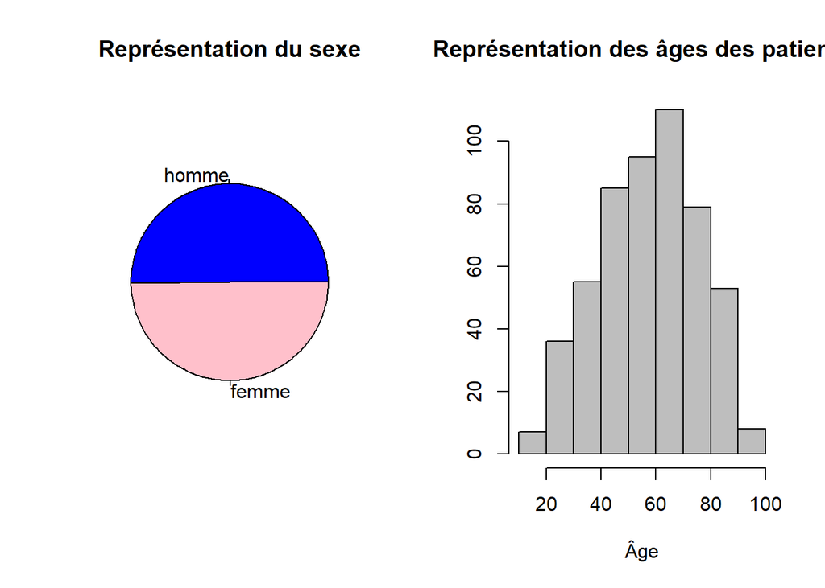

Voici les caractéristiques de la variable: score.relation (=proximité avec le personnel soignant) selon le sexe :

[figure not shown]

```
## data$sexe: homme
## [1] 35.48087
## ------------------------------------------------------------
## data$sexe: femme
## [1] 34.92771
```

Les hommes semblent mieux s’entendre avec le personnel soignant: 35.5/40 en moyenne vs 34.9/40 pour les femmes. On tente de voir s’il y a une corrélation entre ces 2 variables

```
##
##  Two Sample t-test
##
## data:  data$score.relation by data$sexe
## t = 1.1166, df = 347, p-value = 0.2649
## alternative hypothesis: true difference in means between group homme and group femme is not equal to 0
## 95 percent confidence interval:
##  -0.4212101  1.5275370
## sample estimates:
## mean in group homme mean in group femme
##            35.48087            34.92771
```

```
##
##  Fisher's Exact Test for Count Data
##
## data:  data$recommander.b and data$sexe
## p-value = 0.7523
## alternative hypothesis: true odds ratio is not equal to 1
## 95 percent confidence interval:
##  0.7020996 1.6745388
## sample estimates:
## odds ratio
##   1.083487
```

Avec le test de Fisher, on analyse de la même manière la variable binaire : recommander. P-value =0.75 donc les hommes/femmes ne diffèrent pas.

On cherche à expliquer la variable “recommander” en fonction des autres variables par la regression logistique :

```
##
## Call:
## glm(formula = data$recommander.b ~ data$age + data$sexe + data$score.information +
##     data$amelioration.sante + data$amelioration.moral + data$profession +
##     data$service, family = "binomial")
##
## Coefficients:
##                          Estimate Std. Error z value Pr(>|z|)
## (Intercept)             -4.132041   1.016251  -4.066 4.78e-05 ***
## data$age                 0.010876   0.007863   1.383   0.1666
## data$sexefemme           0.435549   0.274599   1.586   0.1127
## data$score.information   0.101498   0.021107   4.809 1.52e-06 ***
## data$amelioration.sante  0.386929   0.182781   2.117   0.0343 *
## data$amelioration.moral  0.269792   0.159343   1.693   0.0904 .
## data$profession         -0.048853   0.078028  -0.626   0.5312
## data$service            -0.021586   0.058126  -0.371   0.7104
## ---
## Signif. codes:  0 '***' 0.001 '**' 0.01 '*' 0.05 '.' 0.1 ' ' 1
##
## (Dispersion parameter for binomial family taken to be 1)
##
##     Null deviance: 391.41  on 313  degrees of freedom
## Residual deviance: 340.68  on 306  degrees of freedom
##   (220 observations effacées parce que manquantes)
## AIC: 356.68
##
## Number of Fisher Scoring iterations: 4
```

La variable “recommander” dépend des variables: score.information, amelioration santé et moral. Les autres variables ont une p-value trop élevée.

```
##
## Call:
## glm(formula = data$recommander.b ~ data$score.information + data$amelioration.sante +
##     data$amelioration.moral, family = "binomial")
##
## Coefficients:
##                         Estimate Std. Error z value Pr(>|z|)
## (Intercept)             -3.47594    0.70149  -4.955 7.23e-07 ***
## data$score.information   0.09663    0.02044   4.727 2.27e-06 ***
## data$amelioration.sante  0.37203    0.17912   2.077   0.0378 *
## data$amelioration.moral  0.26373    0.15659   1.684   0.0921 .
## ---
## Signif. codes:  0 '***' 0.001 '**' 0.01 '*' 0.05 '.' 0.1 ' ' 1
##
## (Dispersion parameter for binomial family taken to be 1)
##
##     Null deviance: 396.77  on 316  degrees of freedom
## Residual deviance: 349.35  on 313  degrees of freedom
##   (217 observations effacées parce que manquantes)
## AIC: 357.35
##
## Number of Fisher Scoring iterations: 4
```

```
##             (Intercept)  data$score.information data$amelioration.sante
##              0.03093275              1.10144732              1.45067007
## data$amelioration.moral
##              1.30178201
```

Ci-dessus les coefficients des 3 variables explicatives. Autrement dit, si le moral du patient s’améliore, on a 1.3X plus de probabilité que ce patient recommande l’hopital.

Maintenant, on essaie de voir s’il existe des corrélations entre les variables.

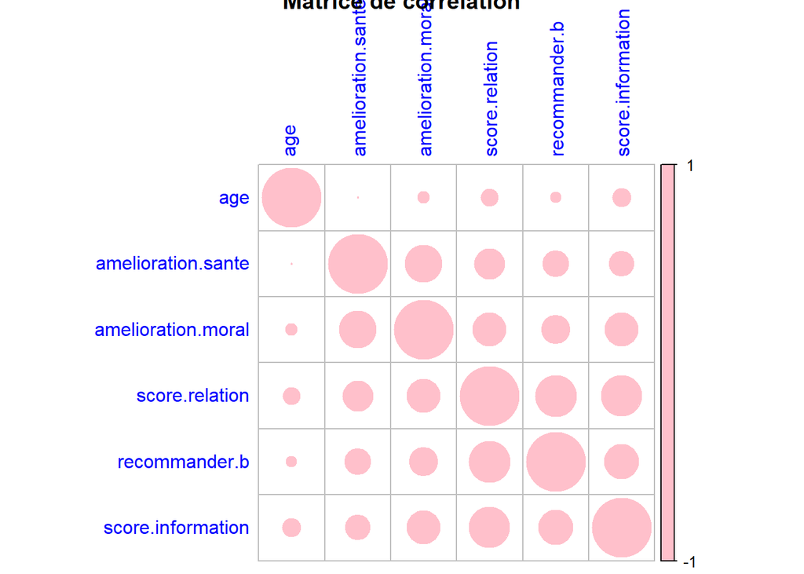

On peut observer une légère corrélation entre les variables :

- amelioration.moral et amelioration.sante
- recommander et score.relation
- score.information et score.relation

Expliquons la variable “recommander” en fonction des autres variables avec l’analyse en composante principale :

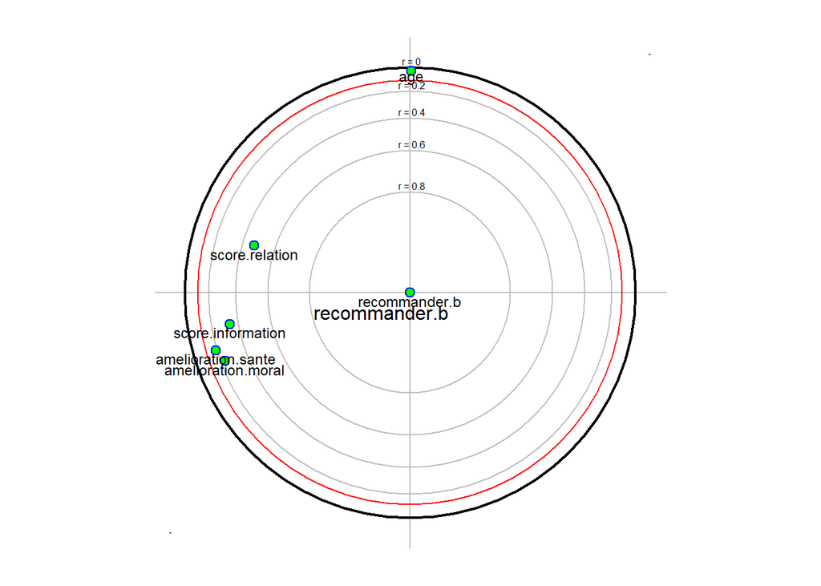

La variable “recommander” est corrélée r=0.5 avec le score.relation. A l’inverse, elle n’est pas du tout liée à l’âge.

Et voici un arbre de classification hierarchique des variables :

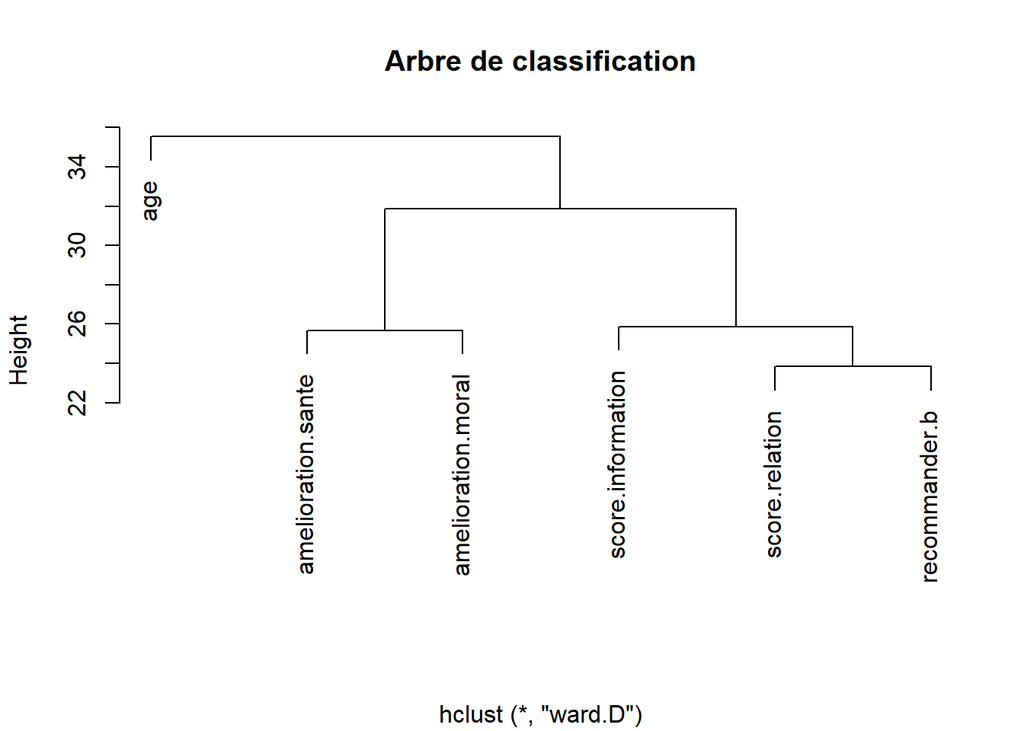

L’âge a peu de lien avec les autres variables. On retrouve les mêmes conclusions que vues précédemment.